## Assignment 4: Streams

### Doug Raffle (dcraffle@mix.wvu.edu)

Generate bivariate normal streaming data with different means represening three clusters.

The objective of this exercise is to gererate, expore, and evaluate streaming data. You need to explain the code in each item and discuss the output. Refer to the help files for specific functions.

1. Generate bivariate normal streaming data with different means represening three clusters. Explain how and what is generated, i.e., explain `dsd`.

```r
library("stream")
set.seed(1002)
dsd <- DSD_Gaussians(k=3, d=2, mu=rbind(c(1.5,1.3),c(1,1),c(1.2,1)))
dsd
```

```
## Mixture of Gaussians
## Class: DSD_Gaussians, DSD_R, DSD_data.frame, DSD
## With 3 clusters in 2 dimensions
```

The function `DSD_Gaussians()` creates an eponymous object (which inherits from `DSD`, the Data Stream Data Generator class) containing parameters used to generate observations from the simulated data stream. The stream simulates three clusters, each made up of a bivariate normal mixture model with means defined the mu matrix and randomly generated covariance matrices.

2. Perform a threshold nearest neighbor micro-clustering. Explain what is generated at every step. Do the evaluations measures provide good fits?

```r
tnn <- DSC_tNN(r=.1)
tnn
```

```
## Threshold nearest-neighbor (tNN)
## Class: DSC_tNN, DSC_Micro, DSC_R, DSC
## Number of micro-clusters: 0
## Number of macro-clusters: 0
```

```r
update(tnn, dsd, n=500, verbose=FALSE)
tnn
```

```
## Threshold nearest-neighbor (tNN)
## Class: DSC_tNN, DSC_Micro, DSC_R, DSC
## Number of micro-clusters: 12
## Number of macro-clusters: 2
```

```r
head(get_centers(tnn))
```

```
##          V1        V2
## 1 1.3596544 1.2955243
## 2 0.9930526 0.8754153
## 3 1.5562792 1.4074121
## 4 0.9064385 1.1081079
## 5 1.4817640 1.2102370
## 6 0.9544307 0.9829623
```

```r
evaluate(tnn, dsd, measure = c("purity", "crand"), n = 500)
```

```
## Evaluation results for micro-clusters.
## Points were assigned to micro-clusters.
##
##    purity     cRand
## 0.9107066 0.2657322
```

First, we initialize tNN object with a threshold of 0.1, we see that by default no clusters have been formed since no data has been processed.

After this, we update the model with 500 observations from our data stream silently and examine the results. We find that two of our macro-clusters were identified along with twelve micro-clusters.

We see that, of the first six clusters, three clusters centered near our first true cluster with means (1.5, 1.3) and three somewhat near our second true cluster with means (1, 1).

Our purity measure is fairly high, so points from the true clusters tend to end up together. The corrected Rand index (a measure of the accuracy of the structure) tells us we’re more dissimilar to our true clusters than similar, this is likely the result of overfitting – we’re finding more clusters than should exist.

3. Plot the micro-clusters. Interpret the plot.

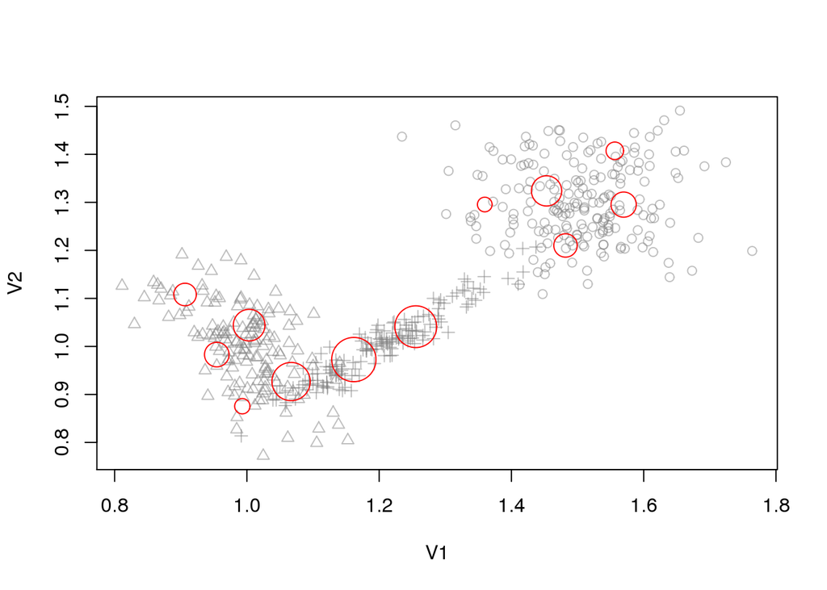

```r
plot(tnn, dsd)
```

The plot shows the cluster centroids represented as circles overlayed on a scatterplot of our distributions. The relative strength of the clusters is represented by their radii.

4. Perform and plot a $k$-means macro cluster. Explain what is generated at every step. Interpret the plot.

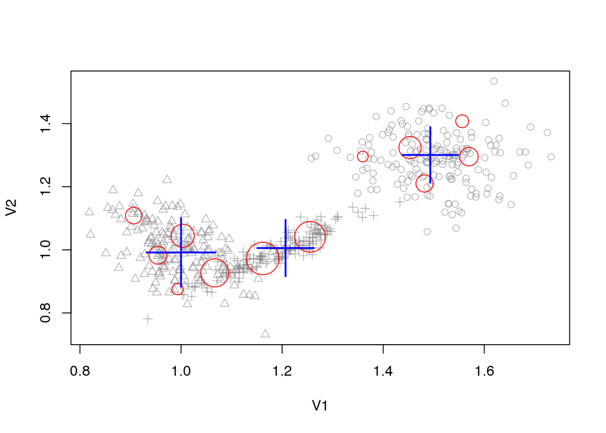

```r
kmeans <- DSC_Kmeans(k=3)
recluster(kmeans, tnn)
plot(kmeans, dsd, type = "both")
```

In the first expression, we initialize a $k$-means cluster object primed to cluster with three centroids.

This clustering scheme is then added to our previously constructed threshold cluster object, which we then visualize.

We see that the centroids of the $k$-means clusters are right where they’re supposed to be: (1, 1), (1.2, 1), and (1.5, 1.3).

5. Do the macro evaluations measures provide good fits? Contrast with 2.

```r
evaluate(kmeans, dsd, measure = c("purity", "crand"), n = 500)
```

```
## Evaluation results for macro-clusters.
## Points were assigned to micro-clusters.
##
##    purity     cRand
## 0.9500816 0.8459560
```

Our purity rating increased by 5% and our corrected Rand score is now up from 27% to 84%, telling us that three macro-clusters is a much better representation of the true structure of our data (as we should expect).